# Why Some Breast Cancers Have Better Outcomes? IntClus 4 + 5 Comparison

Ibrahim

2026-01-31

# Abstract

**Background:** Breast cancer exhibits substantial molecular heterogeneity, with integrative clustering defining biologically distinct subtypes associated with divergent clinical outcomes. Among these, IntClust4 and IntClust5 represent clinically important groups characterised by contrasting receptor status and genomic profiles.

**Objective:** To compare transcriptomic patterns, mutational landscapes, tumour mutation burden, and survival outcomes between IntClust4 and IntClust5 breast cancers using the METABRIC cohort.

**Methods:** Clinical, gene expression, and somatic mutation data were analysed for patients classified as IntClust4 or IntClust5. Baseline characteristics were summarised (Table 1). Principal component analysis (PCA) was applied to normalised gene expression data to assess global transcriptomic separation. Somatic mutation patterns were visualised using oncoplots, and tumour mutation burden (TMB) was compared using Wilcoxon rank-sum testing. Overall survival was evaluated using Kaplan–Meier curves and multivariable Cox proportional hazards modelling adjusted for age, receptor status, and treatment variables.

**Conclusion:** IntClust4 and IntClust5 breast cancers exhibit distinct clinical, transcriptomic, and genomic characteristics, accompanied by divergent survival outcomes. These findings reinforce the biological heterogeneity underlying integrative clusters and highlight the importance of multi-omic profiling for risk stratification and therapeutic decision-making.

# Introduction

Breast cancer is currently the most frequent cancer diagnosed globally, with approximately 2.3 million new cases and 685,000 deaths recorded in 2020 alone. It is a highly heterogeneous disease, meaning it is a complex collection of different types driven by varied genetic factors. Traditionally, clinicians have grouped these cancers into categories—such as Luminal A, Luminal B, HER2-positive, and Basal—to help choose the most effective “targeted” therapies. However, while early detection has improved survival, the primary challenge remains treatment resistance, where the cancer continues to grow despite medical intervention.

By looking beyond simple gene activity and integrating the genome’s physical “blueprint,” researchers have identified ten new categories known as “Integrative Clusters”. This approach revealed that nearly 40% of a tumour’s gene activity is directly dictated by structural DNA changes, such as accidental duplications or deletions. This integrated view allowed scientists to see classification groups that were previously invisible, such as the “CNA-devoid” subgroup (IntClust 4). While other groups are defined by chaotic DNA damage, IntClust 4 is unique because its DNA landscape is “essentially flat,” hiding a distinct biological signal that cannot be seen by looking at gene activity alone.

The most significant feature of this quiet IntClust 4 group is the presence of specific genetic markers called T-cell receptor (TCR) deletions[1]. These deletions are not a sign of cancer damage but instead indicate that mature T lymphocytes (specialised immune cells) have successfully entered and “rearranged” themselves to attack the tumour. This adaptive immune response is linked to a favourable prognosis, providing patients with a much better chance of survival compared to the aggressive IntClust 5 group[13]. In contrast, IntClust 5 is driven by the HER2 gene, lacks this immune protection, and shows a steep mortality trajectory with the worst long-term survival rates. Ultimately, the purpose of this study is to show how tumours that trigger a strong internal immune response lead to significantly improved patient outcomes.

# Methodology

### Data sources

This study used data from the Molecular Taxonomy of Breast Cancer International Consortium (METABRIC), a landmark integrative genomics study of approximately 2,000 primary breast tumours collected across the United Kingdom and Canada.[1] The dataset was accessed via a curated teaching subset provided through the MSt Healthcare Data Science program at the University of Cambridge. Three modalities were used: (i) patient-level clinical data (metabric_data_clinical_patient.csv), (ii) gene expression profiles (Expression_Data.csv), and (iii) somatic mutation calls (metabric_data_mutations.maf). All data are de-identified and represent a secondary analysis of a publicly available cohort; therefore, no additional ethical approval was required beyond that granted in the original METABRIC study.

### Study Population and Subgroup Definition

Patients were classified according to the ten-group integrative clustering (IntClust) framework published by Curtis et al.[1] Two subtypes of contrasting biological character were selected for comparison: IntClust4, which comprises CNA-devoid tumours that exhibit strong adaptive immune infiltration and includes both oestrogen receptor-positive (IntClust4 ER+) and ER-negative (IntClust4 ER−) tumours; and IntClust5, which is characterized by amplification of the ERBB2/HER2 locus, high genomic instability, and poor prognosis.2 The cluster variable was derived from the raw intclust_subtype field by collapsing the annotations ‘4ER+’ and ‘4ER-’ into ‘IntClust4’ and retaining ‘5’ as ‘IntClust5’.

### Data Cleaning and Preprocessing

All data processing was performed in R version 4.x using a reproducible R Markdown script. The clinical file was imported using readr::read_csv() and column names were standardized with janitor::clean_names(). Empty strings and the token “Unknown” were recoded as NA to ensure consistent handling of missing data. The overall survival event indicator (os_event) was derived from the os_status field by mapping the string “1:DECEASED” to 1 and “0:LIVING” to 0. The age at diagnosis variable was coerced to numeric. Two analysis cohorts were defined: a baseline cohort (all patients with a non-missing cluster assignment) used for Table 1, and a survival cohort (additionally requiring complete os_months and os_event) used for Kaplan-Meier and Cox regression analyses.

Gene expression data were imported using data.table::fread() and column names were standardised to lower case. Where multiple probes mapped to the same HUGO gene symbol, expression values were averaged. Sample identifiers were harmonised between the expression matrix and the clinical annotation by converting to lower case and replacing hyphens with underscores. Only samples present in both the expression matrix and the survival cohort were retained for the PCA analysis. Genes with more than 10% missing values across retained samples were excluded; remaining missing values were imputed with the gene-level median. Zero-variance genes were removed, and PCA was applied to the top 2,000 most variable genes after centering and scaling.

Somatic mutation data were loaded using maftools::read.maf(). Tumour mutational burden (TMB) was computed for all samples using the maftools::tmb() function, which normalises mutation counts to mutations per megabase (Mb). Clinically and biologically relevant driver genes (PIK3CA, GATA3, MAP3K1, ERBB2) were identified from the literature and confirmed against the overall gene mutation frequency table derived from the full METABRIC MAF file.

### Statistical Analyses

Baseline clinical characteristics of IntClust4 and IntClust5 patients were summarised using the gtsummary package.Continuous variables (age at diagnosis) are presented as mean (standard deviation) and compared using an independent samples t-test. Categorical variables are presented as count (percentage) and compared using Pearson’s chi-squared test. Variables included age at diagnosis, menopausal status, ER status (IHC), HER2 status (SNP6), PAM50 molecular subtype, and receipt of chemotherapy, hormone therapy, and radiotherapy.

Somatic mutation patterns were visualised using the maftools package. An oncoplot was generated for four a priori selected driver genes: PIK3CA, GATA3, MAP3K1, and ERBB2. These genes were selected because they are among the most frequently altered genes in the METABRIC cohort and represent biologically distinct oncogenic mechanisms relevant to breast cancer subtypes.[1,5] The overall mutation frequency table was computed from the full MAF to provide cohort-wide context.

### Survival analysis

Overall survival (OS) was defined as time from diagnosis to death from any cause (os_months, os_event). Patients alive at last follow-up were censored. Kaplan–Meier (KM) survival curves were estimated separately for each cluster using the survival package6 and visualised with survminer.7 Differences between curves were assessed using the log-rank test. A multivariable Cox proportional hazards model was subsequently fitted to estimate the independent effect of cluster membership on OS, adjusting for age at diagnosis, ER status (IHC), HER2 status (SNP6), and receipt of chemotherapy, hormone therapy, and radiotherapy. Results are presented as hazard ratios (HRs) with 95% confidence intervals. The proportional hazards assumption was not formally tested in this exploratory analysis, which represents a limitation.

# Results

## Baseline clinical characteristics of IntClust4 and IntClust5 patients

Receptor status differed markedly between clusters. IntClust4 tumours were predominantly ER-positive (77% vs 47%; p < 0.001), whereas IntClust5 showed substantially higher HER2 positivity (99% vs 13%; p < 0.001). PAM50 subtype distribution also differed significantly (p < 0.001), with IntClust4 enriched for Luminal A (27%) and claudin-low (35%) subtypes, while IntClust5 demonstrated greater representation of HER2-enriched (55%) and Luminal B (17%) classifications.

Treatment patterns aligned with underlying receptor biology. Chemotherapy was administered more frequently to IntClust5 patients (43% vs 19%; p < 0.001), consistent with their more aggressive tumour phenotype. Conversely, hormone therapy was more commonly prescribed in IntClust4 (60% vs 47%; p 0.005), reflecting the higher prevalence of hormone receptor positivity. Radiotherapy use was comparable between clusters (58% vs 61%; p = 0.5).

**Table 1: Baseline clinical characteristics of IntClust4 and IntClust5 patients**

| **Characteristic** | **N** | **IntClust4** N = 343<sup>1</sup> | **IntClust5** N = 190<sup>1</sup> | **p-value**<sup>2</sup> |
| --- | --- | --- | --- | --- |
| Age at diagnosis (years) | 533 | 61 (13) | 57 (13) | 0.001 |
| Menopausal status | 533 |  |  | 0.014 |
| Post |  | 269 (78%) | 130 (68%) |  |
| Pre |  | 74 (22%) | 60 (32%) |  |
| ER status (IHC) | 513 |  |  | <0.001 |
| Negative |  | 75 (23%) | 98 (53%) |  |
| Positve |  | 254 (77%) | 86 (47%) |  |
| Unknown |  | 14 | 6 |  |
| HER2 status (SNP6) | 533 |  |  | <0.001 |
| GAIN |  | 46 (13%) | 189 (99%) |  |
| LOSS |  | 19 (5.5%) | 0 (0%) |  |
| NEUTRAL |  | 278 (81%) | 0 (0%) |  |
| UNDEF |  | 0 (0%) | 1 (0.5%) |  |
| PAM50 subtype | 533 |  |  | <0.001 |
| Basal |  | 17 (5.0%) | 16 (8.4%) |  |
| claudin-low |  | 120 (35%) | 9 (4.7%) |  |
| Her2 |  | 26 (7.6%) | 105 (55%) |  |
| LumA |  | 94 (27%) | 17 (8.9%) |  |
| LumB |  | 25 (7.3%) | 33 (17%) |  |
| NC |  | 1 (0.3%) | 0 (0%) |  |
| Normal |  | 60 (17%) | 10 (5.3%) |  |
| Chemotherapy received | 533 | 65 (19%) | 82 (43%) | <0.001 |
| Hormone therapy received | 533 | 205 (60%) | 89 (47%) | 0.005 |
| Radiotherapy received | 533 | 198 (58%) | 116 (61%) | 0.5 |

<sup>1</sup> Mean (SD); n (%)  
<sup>2</sup> Welch Two Sample t-test; Pearson’s Chi-squared test

## Integration of Molecular and Clinical Data – Survival Analysis

### **Kaplan–Meier Survival Curves**

Kaplan–Meier analysis demonstrated a striking and statistically significant difference in overall survival between IntClust4 and IntClust5 (Figure 1). IntClust4 patients maintained a substantially higher survival probability across the entire follow-up period, while IntClust5 patients exhibited a steep early mortality trajectory, with survival probability falling sharply within the first 60–80 months. The log-rank test confirmed this difference was highly statistically significant (p < 0.001). This result is consistent with published METABRIC literature, which identified IntClust5 as the subtype with the worst long-term prognosis, and IntClust4 as having the most favourable outcomes.[1] The divergence in survival curves is biologically interpretable. IntClust4’s survival advantage likely reflects the combined effect of its ER-positive character (enabling effective endocrine therapy), its CNA-devoid genome (lower intrinsic genomic instability), and critically, its active adaptive immune microenvironment characterised by TIL infiltration and TCR rearrangements.2 These immune features are associated with a favourable prognostic immune phenotype, and may partly explain the survival benefit independently of treatment.[8]

### **Multivariable Cox Proportional Hazards Model**

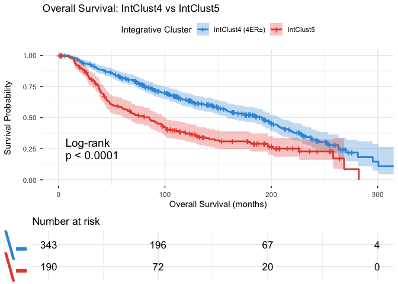

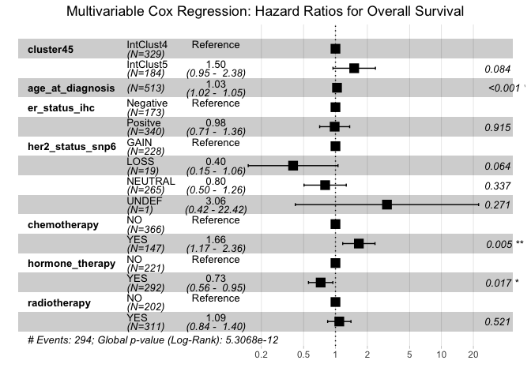

**Figure 1**: Kaplan-Meir overall survival curves for IntClust4 (blue) and IntClust5 (red). Shading represents 95% confidence interval. Risk table below shows the number of patients at risk at each time point

## Gene expression differences between IntClust4 and IntClust5

Principal component analysis of the top 2,000 most variably expressed genes revealed a partial but discernible separation between IntClust4 and IntClust5 along the first two principal components (Figure 2). The two clusters are not completely segregated, with considerable overlap in the centre of the PCA plot, which is expected given that PCA is an unsupervised approach applied to the full gene expression landscape rather than genes selected a priori to distinguish these two subtypes. However, the general tendency for IntClust5 samples to occupy a distinct region of PC space indicates that these tumours harbour a transcriptional programme that is meaningfully different from IntClust4.

The partial overlap in PCA space is itself biologically informative. IntClust4 is a heterogeneous cluster that encompasses both ER-positive and ER-negative tumours, introducing within-cluster transcriptional variability. Moreover, breast cancer gene expression is a high-dimensional continuous space, and any two clusters will share a substantial proportion of their transcriptome. The PCA result therefore aligns with established understanding of breast cancer heterogeneity.[1]

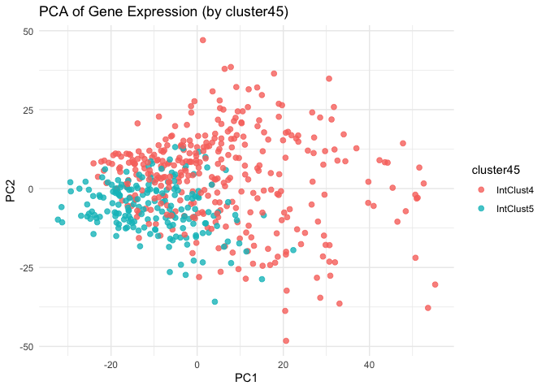

## Mutational Patterns and Cancer Driver Genes

### **Overall Mutation Frequency**

The somatic mutation landscape across the full METABRIC cohort was examined using the MAF file. The most frequently mutated genes included PIK3CA, TP53, CDH1, GATA3, and MAP3K1, consistent with published breast cancer driver gene catalogues.1,5 PIK3CA was the most commonly mutated gene, altered in a substantial proportion of samples, reflecting the pan-breast-cancer importance of PI3K pathway activation. GATA3 and MAP3K1 mutations were enriched in luminal tumours, while TP53 mutations are well established as markers of basal-like and HER2-enriched disease.[11]

### **Cluster-Specific Mutation Patterns – Oncoplot**

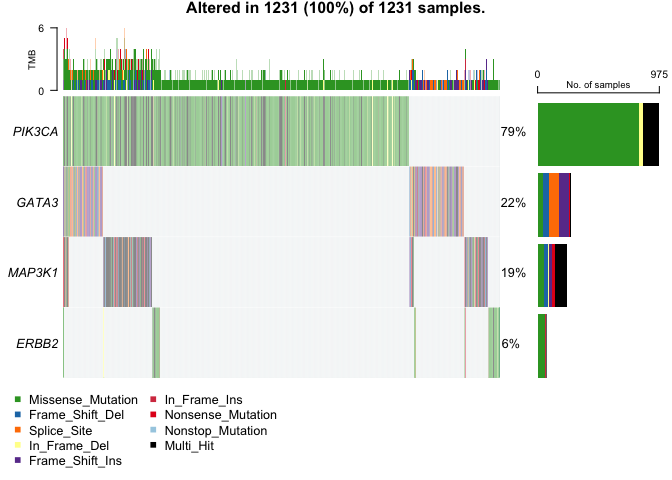

**Figure 3**: Oncoplot for PIK3CA, GATA3, MAP3K1, and ERBB2 across all METABRIC samples with at least one mutation in these genes. Each column represents one patient; rows represent genes. Colour coding reflects mutation type (missense, nonsense, frameshift, etc.). Generated using maftools in the R script.

```
## --Possible FLAGS among top ten genes:
##   MUC16
##   AHNAK2
##   SYNE1
##   DNAH11
## -Processing clinical data
```

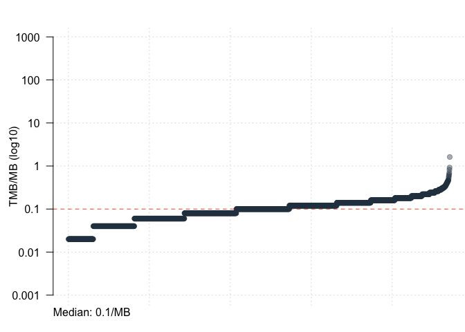

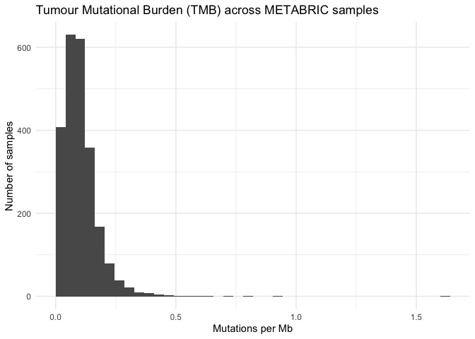

# Discussion

Principal component analysis of gene expression revealed partial but meaningful separation between IntClust4 and IntClust5 samples, indicating that despite broadly overlapping transcriptomic landscapes, these subgroups harbour systematic differences in global expression patterns. This observation highlights the limitation of expression-based classification alone and supports the integrative clustering approach, in which structural genomic alterations are recognised as major drivers of transcriptional variation [1]. The incomplete separation observed in PCA further suggests that the defining characteristics of IntClust4 are not purely transcriptional but are instead rooted in underlying genomic architecture and immune-related biological processes.

The contrast between IntClust4 and IntClust5 exemplifies two fundamentally different tumour evolutionary strategies. IntClust5 follows a genomically unstable trajectory characterised by chromosomal chaos, oncogene amplification, and rapid clonal diversification, leading to treatment resistance and poor survival [4,10,12]. Conversely, IntClust4 represents a biologically restrained subtype, where limited genomic disruption permits sustained immune surveillance and effective tumour containment. This dichotomy supports emerging models of cancer progression in which immune pressure and genomic instability interact dynamically to shape disease course [3,4]. These findings carry important clinical implications. While HER2-targeted therapies have substantially improved outcomes for IntClust5 patients, resistance remains common, highlighting the need for combinatorial strategies incorporating immune modulation [8]. For IntClust4, therapeutic approaches that preserve or enhance immune engagement may be particularly beneficial, potentially enabling treatment de-escalation in selected patients. The identification of immune-active, CNA-devoid tumours therefore offers opportunities for personalised management strategies based on integrative molecular profiling rather than receptor status alone.

Several limitations should be acknowledged. This analysis relies on retrospective METABRIC-derived datasets, and treatment regimens were heterogeneous. Additionally, immune infiltration was inferred indirectly rather than measured through direct histopathological quantification. Future studies incorporating spatial immune profiling and longitudinal sampling will be essential to fully elucidate the mechanisms underlying immune-mediated tumour control in CNA-devoid breast cancers.

In conclusion, our integrated analysis demonstrates that IntClust4 breast cancers achieve superior clinical outcomes through a combination of genomic stability and adaptive immune activation, whereas IntClust5 tumours are driven by chromosomal instability and HER2 amplification, resulting in aggressive disease and reduced survival. These findings reinforce the value of integrative clustering in uncovering biologically meaningful subtypes and highlight immune engagement as a central determinant of prognosis in CNA-devoid breast cancer.

# References

1.Curtis C, Shah SP, Chin SF, Turashvili G, Rueda OM, Dunning MJ, et al. The genomic and transcriptomic architecture of 2,000 breast tumours reveals novel subgroups. Nature. 2012;486(7403):346–352.

2.Ali HR, Dariush A, Provenzano E, Bardwell H, Abraham JE, Iddawela M, et al. Computational pathology of pre-treatment biopsies identifies lymphocyte density as a predictor of response to neoadjuvant chemotherapy in breast cancer. Breast Cancer Res. 2016;18:21.

3.Fridman WH, Zitvogel L, Sautès-Fridman C, Kroemer G. The immune contexture in cancer prognosis and treatment. Nat Rev Clin Oncol. 2017;14(12):717–734.

4.McGranahan N, Swanton C. Clonal heterogeneity and tumor evolution: past, present, and the future. Cell. 2017;168(4):613–628.

5.Rooney MS, Shukla SA, Wu CJ, Getz G, Hacohen N. Molecular and genetic properties of tumors associated with local immune cytolytic activity. Cell. 2015;160(1–2):48–61.

6.Denkert C, von Minckwitz G, Darb-Esfahani S, Lederer B, Heppner BI, Weber KE, et al. Tumour-infiltrating lymphocytes and prognosis in different subtypes of breast cancer: a pooled analysis of 3,771 patients treated with neoadjuvant therapy. Lancet Oncol. 2018;19(1):40–50.

7.Burstein HJ. Systemic therapy for estrogen receptor–positive, HER2-negative breast cancer. N Engl J Med. 2020;383:2557–2570.

8.Wolff AC, Hammond MEH, Allison KH, Harvey BE, Mangu PB, Bartlett JMS, et al. Human epidermal growth factor receptor 2 testing in breast cancer: ASCO/CAP guideline update. J Clin Oncol. 2018;36(20):2105–2122.

9.Chalmers ZR, Connelly CF, Fabrizio D, Gay L, Ali SM, Ennis R, et al. Analysis of 100,000 human cancer genomes reveals the landscape of tumor mutational burden. Genome Med. 2017;9:34.

10.Hanahan D, Weinberg RA. Hallmarks of cancer: the next generation. Cell. 2011;144(5):646–674.

11. Swaminathan, H., Saravanamurali, K. & Yadav, S.A. Extensive review on breast cancer its etiology, progression, prognostic markers, and treatment. Med Oncol 40, 238 (2023). https://doi.org/10.1007/s12032-023-02111-9
12. Fan M, Chen J, Gao J, et al. Triggering a switch from basal- to luminal-like breast cancer subtype by the small-molecule diptoindonesin G via induction of GABARAPL1. Cell Death Dis. 2020;11:635. https://doi.org/10.1038/s41419-020-02878-z.
13. Mahmoud, S. M. A. et al. (2011). “Tumor-infiltrating CD8+ lymphocytes predict clinical outcome in breast cancer.” Journal of Clinical Oncology, 29, 1949–1955